# Analyzing warehouse operational efficiency

```python
import pandas as pd
import numpy as np
import matplotlib.pyplot as plt
import seaborn as sns
from scipy import stats
from scipy.stats import skew, kurtosis
import warnings

# Settings
warnings.filterwarnings('ignore')
sns.set_style('darkgrid')  # Replaces problematic plt.style.use
sns.set_palette('husl')    # Keeps your palette

# Load Dataset
df = pd.read_excel(r"C:\Users\snara\PycharmProjects\helloworld\Analysing warehouse operational efficiency\SupplyFlow FMCG Solutions.xlsx")
print("Dataset shape:", df.shape)
print("\nFirst few rows:")
print(df.head())
print("\nColumn names and types:")
print(df.dtypes)
print("\nDataset Info:")
print(df.info())
```

```
Dataset shape: (25000, 24)

First few rows:
  Ware_house_ID WH_Manager_ID Location_type WH_capacity_size   zone  \
0     WH_100000     EID_50000         Urban            Small   West
1     WH_100001     EID_50001         Rural            Large  North
2     WH_100002     EID_50002         Rural              Mid  South
3     WH_100003     EID_50003         Rural              Mid  North
4     WH_100004     EID_50004         Rural            Large  North

  WH_regional_zone  num_refill_req_l3m  transport_issue_l1y  \
0           Zone 6                 3.0                  1.0
1           Zone 5                 0.0                  0.0
2           Zone 2                 1.0                  0.0
3           Zone 3                 7.0                  4.0
4           Zone 5                 3.0                  1.0

   Competitor_in_mkt  retail_shop_num  ... electric_supply  dist_from_hub  \
0                2.0           4651.0  ...             1.0           91.0
1                4.0           6217.0  ...             1.0          210.0
2                4.0           4306.0  ...             0.0          161.0
3                2.0           6000.0  ...             0.0          103.0
4                2.0           4740.0  ...             1.0          112.0

   workers_num  wh_est_year  storage_issue_reported_l3m  temp_reg_mach  \
0         29.0          NaN                        13.0            0.0
1         31.0          NaN                         4.0            0.0
2         37.0          NaN                        17.0            0.0
3         21.0          NaN                        17.0            1.0
4         25.0       2009.0                        18.0            0.0

   approved_wh_govt_certificate  wh_breakdown_l3m  govt_check_l3m  \
0                             A               5.0            15.0
1                             A               3.0            17.0
2                             A               6.0            22.0
3                            A+               3.0            27.0
4                             C               6.0            24.0

   product_wg_ton
0         17115.0
```

[output cut: 52 more lines]

```
 12  flood_impacted                25000 non-null  float64
 13  flood_proof                   25000 non-null  float64
 14  electric_supply               25000 non-null  float64
 15  dist_from_hub                 25000 non-null  float64
 16  workers_num                   24010 non-null  float64
 17  wh_est_year                   13119 non-null  float64
 18  storage_issue_reported_l3m    25000 non-null  float64
 19  temp_reg_mach                 25000 non-null  float64
 20  approved_wh_govt_certificate  24092 non-null  object
 21  wh_breakdown_l3m              25000 non-null  float64
 22  govt_check_l3m                25000 non-null  float64
 23  product_wg_ton                25000 non-null  float64
dtypes: float64(16), object(8)
memory usage: 4.6+ MB
None
```

```python
import pandas as pd
import numpy as np
from scipy.stats import skew, kurtosis

# Data cleaning (one-time)
print("Duplicate Rows:")
print(df.duplicated().sum())
df_clean = df.drop_duplicates()
print(f"Dataset shape after removing duplicates: {df_clean.shape}")

# Prepare columns
numeric_cols = df_clean.select_dtypes(include=[np.number]).columns.tolist()
categorical_cols = df_clean.select_dtypes(include=['object']).columns.tolist()

# Missing values (only columns with missing)
print("\nMissing Values:")
missing_mask = df_clean.isnull().sum() > 0
missing_data = pd.DataFrame({
    'Column': df_clean.columns[missing_mask],
    'Missing_Count': df_clean.isnull().sum()[missing_mask],
    'Percentage': (df_clean.isnull().sum()[missing_mask] / len(df_clean)) * 100
})
print(missing_data)

# Basic statistics
print("\nBasic Statistics:")
print(df_clean.describe())

# Column lists
print(f"\nNumeric columns ({len(numeric_cols)}): {numeric_cols}")
print(f"Categorical columns ({len(categorical_cols)}): {categorical_cols}")

# Numeric analysis (vectorized stats)
print("\n=== NUMERIC COLUMNS ANALYSIS ===")
numeric_df = df_clean[numeric_cols].describe()
skew_vals = pd.Series(skew(df_clean[numeric_cols].dropna(), axis=0), index=numeric_cols)
kurt_vals = pd.Series(kurtosis(df_clean[numeric_cols].dropna(), axis=0), index=numeric_cols)

for col in numeric_cols:
    print(f"\n{col}:")
    print(f"  Min: {numeric_df.loc['min', col]:.2f}")
    print(f"  Max: {numeric_df.loc['max', col]:.2f}")
    print(f"  Mean: {numeric_df.loc['mean', col]:.2f}")
    print(f"  Median: {numeric_df.loc['50%', col]:.2f}")
    print(f"  Std: {numeric_df.loc['std', col]:.2f}")
    print(f"  Skewness: {skew_vals[col]:.2f}")
    print(f"  Kurtosis: {kurt_vals[col]:.2f}")
```

```
Duplicate Rows:
0
Dataset shape after removing duplicates: (25000, 24)

Missing Values:
                                                    Column  Missing_Count  \
workers_num                                    workers_num            990
wh_est_year                                    wh_est_year          11881
approved_wh_govt_certificate  approved_wh_govt_certificate            908

                              Percentage
workers_num                        3.960
wh_est_year                       47.524
approved_wh_govt_certificate       3.632

Basic Statistics:
       num_refill_req_l3m  transport_issue_l1y  Competitor_in_mkt  \
count        25000.000000         25000.000000       25000.000000
mean             4.089040             0.773680           3.104200
std              2.606612             1.199449           1.141663
min              0.000000             0.000000           0.000000
25%              2.000000             0.000000           2.000000
50%              4.000000             0.000000           3.000000
75%              6.000000             1.000000           4.000000
max              8.000000             5.000000          12.000000

       retail_shop_num  distributor_num  flood_impacted   flood_proof  \
count     25000.000000     25000.000000    25000.000000  25000.000000
mean       4985.711560        42.418120        0.098160      0.054640
std        1052.825252        16.064329        0.297537      0.227281
min        1821.000000        15.000000        0.000000      0.000000
25%        4313.000000        29.000000        0.000000      0.000000
50%        4859.000000        42.000000        0.000000      0.000000
75%        5500.000000        56.000000        0.000000      0.000000
max       11008.000000        70.000000        1.000000      1.000000

       electric_supply  dist_from_hub   workers_num   wh_est_year  \
count     25000.000000   25000.000000  24010.000000  13119.000000
mean          0.656880     163.537320     28.944398   2009.383185
std           0.474761      62.718609      7.872534      7.528230
```

[output cut: 159 more lines]

```
  Max: 32.00
  Mean: 18.81
  Median: 21.00
  Std: 8.63
  Skewness: -0.38
  Kurtosis: -1.04

product_wg_ton:
  Min: 2065.00
  Max: 55151.00
  Mean: 22102.63
  Median: 22101.00
  Std: 11607.76
  Skewness: 0.23
  Kurtosis: -0.60
```

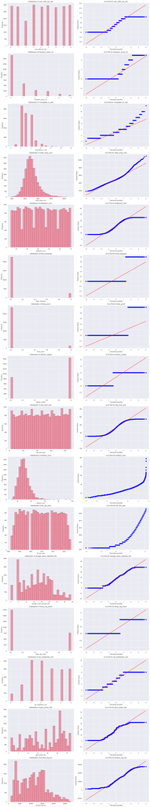

[figure not shown]

```python
# Distribution Plots - Improved
n_numeric = len(numeric_cols)
fig, axes = plt.subplots(n_numeric, 2, figsize=(15, 5*n_numeric))

# Handle single column case automatically
if n_numeric == 1:
    axes = axes.reshape(1, -1)

for idx, col in enumerate(numeric_cols):
    # Histogram
    axes[idx, 0].hist(df_clean[col], bins=30, edgecolor='black', alpha=0.7)
    axes[idx, 0].set_title(f'Distribution of {col}')
    axes[idx, 0].set_xlabel(col)
    axes[idx, 0].set_ylabel('Frequency')

    # Q-Q Plot
    stats.probplot(df_clean[col], dist="norm", plot=axes[idx, 1])
    axes[idx, 1].set_title(f'Q-Q Plot for {col}')

plt.tight_layout()
plt.show()

# Categorical Plots
n_categorical = len(categorical_cols)
fig, axes = plt.subplots(n_categorical, 1, figsize=(12, 4*n_categorical))

# Handle single column case automatically
if n_categorical == 1:
    axes = [axes]

for idx, col in enumerate(categorical_cols):
    df_clean[col].value_counts().plot(kind='bar', ax=axes[idx], edgecolor='black')
    axes[idx].set_title(f'Distribution of {col}')
    axes[idx].set_xlabel(col)
    axes[idx].set_ylabel('Count')
    axes[idx].tick_params(axis='x', rotation=45)

plt.tight_layout()
plt.show()
```

```python
from sklearn.preprocessing import LabelEncoder

# Outlier Detection - Vectorized (single pass)
print("# Outlier Detection")
Q1 = df_clean[numeric_cols].quantile(0.25)
Q3 = df_clean[numeric_cols].quantile(0.75)
IQR = Q3 - Q1

# Calculate outliers for all columns at once
lower_bounds = Q1 - 1.5 * IQR
upper_bounds = Q3 + 1.5 * IQR
outlier_counts = ((df_clean[numeric_cols] < lower_bounds) | (df_clean[numeric_cols] > upper_bounds)).sum()

for col in numeric_cols:
    outliers = outlier_counts[col]
    print(f"{col}: {outliers} outliers ({(outliers/len(df_clean))*100:.2f}%)")

# Outlier Replacement - Single operation per column
df_processed = df_clean.copy()
for col in numeric_cols:
    Q1_col = df_processed[col].quantile(0.25)
    IQR_col = df_processed[col].quantile(0.75) - Q1_col
    lower_bound = Q1_col - 1.5 * IQR_col
    upper_bound = Q1_col + 1.5 * IQR_col + IQR_col  # Q3 + 1.5*IQR

    df_processed[col] = np.where(
        (df_processed[col] < lower_bound) | (df_processed[col] > upper_bound),
        df_processed[col].median(),
        df_processed[col]
    )

# Label Encoding - Single encoder instance, proper handling
le = LabelEncoder()
for col in categorical_cols:
    df_processed[col + '_encoded'] = le.fit_transform(df_processed[col].astype(str))

print("\nCategorical variables encoded. Dataset ready for correlation analysis.")
```

```
# Outlier Detection
num_refill_req_l3m: 0 outliers (0.00%)
transport_issue_l1y: 2943 outliers (11.77%)
Competitor_in_mkt: 96 outliers (0.38%)
retail_shop_num: 948 outliers (3.79%)
distributor_num: 0 outliers (0.00%)
flood_impacted: 2454 outliers (9.82%)
flood_proof: 1366 outliers (5.46%)
electric_supply: 0 outliers (0.00%)
dist_from_hub: 0 outliers (0.00%)
workers_num: 607 outliers (2.43%)
wh_est_year: 0 outliers (0.00%)
storage_issue_reported_l3m: 0 outliers (0.00%)
temp_reg_mach: 0 outliers (0.00%)
wh_breakdown_l3m: 0 outliers (0.00%)
govt_check_l3m: 0 outliers (0.00%)
product_wg_ton: 0 outliers (0.00%)

Categorical variables encoded. Dataset ready for correlation analysis.
```

ASSIGNMENT: The objective is to create a trustworthy prediction model and pinpoint the main factors influencing warehouse performance, with a focus on the product_wg_ton metric. I'll start by carefully preparing the data for analysis, which includes encoding categorical features into numerical format, eliminating outlier distortions, and strategically impute missing values. After that, Random Forest will be used as the basis for a baseline regression model aimed at product_wg_ton predictions as well as a feature selection mechanism to identify the most influential variables. In order to improve operational decision-making, the analysis culminates with model validation utilizing standard metrics, thorough feature importance rankings, and useful business recommendations derived directly from the results.

Model Configuration and Target Defined Subtask: Assign product_wg_ton as the main variable to be predicted (y). To prepare for machine learning, create a df_model DataFrame from df_clean. Since Ware_house_ID and WH_Manager_ID are unique identifiers that don't contribute to performance patterns, remove them from the df_model non-predictive identifier columns.

Reasoning: Using the cleaned dataset, I will create a dedicated modeling copy called df_model, set product_wg_ton as my dependent variable y, and remove the ID columns "Ware_house_ID" and "WH_Manager_ID," which are useless for predicting warehouse throughput.

```python
y = df_clean['product_wg_ton']
df_model = df_clean.copy()
df_model = df_model.drop(columns=['Ware_house_ID', 'WH_Manager_ID'])

print("Shape of df_model:", df_model.shape)
print("First few rows of df_model after dropping ID columns:")
print(df_model.head())
print("First few rows of target variable y:")
print(y.head())
```

```
Shape of df_model: (25000, 22)
First few rows of df_model after dropping ID columns:
  Location_type WH_capacity_size   zone WH_regional_zone  num_refill_req_l3m  \
0         Urban            Small   West           Zone 6                 3.0
1         Rural            Large  North           Zone 5                 0.0
2         Rural              Mid  South           Zone 2                 1.0
3         Rural              Mid  North           Zone 3                 7.0
4         Rural            Large  North           Zone 5                 3.0

   transport_issue_l1y  Competitor_in_mkt  retail_shop_num  wh_owner_type  \
0                  1.0                2.0           4651.0         Rented
1                  0.0                4.0           6217.0  Company Owned
2                  0.0                4.0           4306.0  Company Owned
3                  4.0                2.0           6000.0         Rented
4                  1.0                2.0           4740.0  Company Owned

   distributor_num  ...  electric_supply  dist_from_hub  workers_num  \
0             24.0  ...              1.0           91.0         29.0
1             47.0  ...              1.0          210.0         31.0
2             64.0  ...              0.0          161.0         37.0
3             50.0  ...              0.0          103.0         21.0
4             42.0  ...              1.0          112.0         25.0

   wh_est_year  storage_issue_reported_l3m  temp_reg_mach  \
0          NaN                        13.0            0.0
1          NaN                         4.0            0.0
2          NaN                        17.0            0.0
3          NaN                        17.0            1.0
4       2009.0                        18.0            0.0

   approved_wh_govt_certificate  wh_breakdown_l3m govt_check_l3m  \
0                             A               5.0           15.0
1                             A               3.0           17.0
2                             A               6.0           22.0
3                            A+               3.0           27.0
4                             C               6.0           24.0

   product_wg_ton
0         17115.0
1          5074.0
2         23137.0
3         22115.0
4         24071.0

[5 rows x 22 columns]
First few rows of target variable y:
0    17115.0
1     5074.0
2    23137.0
3    22115.0
4    24071.0
Name: product_wg_ton, dtype: float64
```

Handle Missing Data Imputation Subtask: Resolve missing values within df_model: Fill gaps in workers_num (numerical feature) using its median value. Replace missing entries in approved_wh_govt_certificate (categorical feature) with the most frequent category (mode). Engineer a new wh_age feature by calculating current year (2023) minus wh_est_year; then impute any missing wh_age values with its median. Remove the original wh_est_year column once wh_age is created.

Justification: This involves median imputation for workers_num, mode imputation for approved_wh_govt_certificate, deriving wh_age from wh_est_year followed by median fill for its missing values, and dropping wh_est_year afterward. All steps execute sequentially in one cohesive code section.

```python
#Load and initially clean data
import pandas as pd
import numpy as np

df = pd.read_excel(r"C:\Users\snara\PycharmProjects\helloworld\Analysing warehouse operational efficiency\SupplyFlow FMCG Solutions.xlsx")
df_clean = df.drop_duplicates()
print(f"Dataset shape after removing duplicates: {df_clean.shape}")
```

```
Dataset shape after removing duplicates: (25000, 24)
```

```python
#Create df_model and handle missing values
df_model = df_clean.drop(columns=['Ware_house_ID', 'WH_Manager_ID']).copy()
y = df_model['product_wg_ton']
X = df_model.drop(columns=['product_wg_ton'])

# Impute missing values efficiently
median_workers_num = df_model['workers_num'].median()
mode_approved_wh_govt_certificate = df_model['approved_wh_govt_certificate'].mode()[0]

df_model['workers_num'] = df_model['workers_num'].fillna(median_workers_num)
df_model['approved_wh_govt_certificate'] = df_model['approved_wh_govt_certificate'].fillna(mode_approved_wh_govt_certificate)

# Create wh_age and impute
df_model['wh_age'] = (2023 - df_model['wh_est_year']).fillna((2023 - df_model['wh_est_year']).median())
df_model = df_model.drop(columns=['wh_est_year'])

print("\nMissing values after imputation:")
print(df_model.isnull().sum()[df_model.isnull().sum() > 0])
print("\nFirst few rows of df_model with new 'wh_age' column:")
print(df_model.head())
```

```
Missing values after imputation:
Series([], dtype: int64)

First few rows of df_model with new 'wh_age' column:
  Location_type WH_capacity_size   zone WH_regional_zone  num_refill_req_l3m  \
0         Urban            Small   West           Zone 6                 3.0
1         Rural            Large  North           Zone 5                 0.0
2         Rural              Mid  South           Zone 2                 1.0
3         Rural              Mid  North           Zone 3                 7.0
4         Rural            Large  North           Zone 5                 3.0

   transport_issue_l1y  Competitor_in_mkt  retail_shop_num  wh_owner_type  \
0                  1.0                2.0           4651.0         Rented
1                  0.0                4.0           6217.0  Company Owned
2                  0.0                4.0           4306.0  Company Owned
3                  4.0                2.0           6000.0         Rented
4                  1.0                2.0           4740.0  Company Owned

   distributor_num  ...  electric_supply  dist_from_hub  workers_num  \
0             24.0  ...              1.0           91.0         29.0
1             47.0  ...              1.0          210.0         31.0
2             64.0  ...              0.0          161.0         37.0
3             50.0  ...              0.0          103.0         21.0
4             42.0  ...              1.0          112.0         25.0

   storage_issue_reported_l3m  temp_reg_mach  approved_wh_govt_certificate  \
0                        13.0            0.0                             A
1                         4.0            0.0                             A
2                        17.0            0.0                             A
3                        17.0            1.0                            A+
4                        18.0            0.0                             C

   wh_breakdown_l3m govt_check_l3m  product_wg_ton  wh_age
0               5.0           15.0         17115.0    14.0
1               3.0           17.0          5074.0    14.0
2               6.0           22.0         23137.0    14.0
3               3.0           27.0         22115.0    14.0
4               6.0           24.0         24071.0    14.0

[5 rows x 22 columns]
```

Justification : The new feature was engineered and missing values were successfully fixed by the previous preprocessing steps. The remaining categorical columns in the df_model must be converted via Label Encoding in the preprocessing step that follows the main workflow in order for machine learning algorithms to use them. To avoid data leakage during model training, product_wg_ton, our target variable, needs to be removed from the feature matrix df_model.

```python
from sklearn.preprocessing import LabelEncoder

# Create encoded version of df_model
df_model_encoded = df_model.copy()

# Identify categorical columns
categorical_cols_model = df_model_encoded.select_dtypes(include=['object']).columns.tolist()

# Initialize LabelEncoder
le = LabelEncoder()

# Encode categorical columns
for col in categorical_cols_model:
    df_model_encoded[col + '_encoded'] = le.fit_transform(df_model_encoded[col])
    df_model_encoded.drop(columns=[col], inplace=True)

# Drop target variable
df_model_encoded.drop(columns=['product_wg_ton'], inplace=True)

# output
print("Shape of df_model_encoded:", df_model_encoded.shape)
print("First few rows of df_model_encoded after encoding categorical features and dropping target variable:")
print(df_model_encoded.head())
print("Data types in df_model_encoded:")
print(df_model_encoded.dtypes)
```

```
Shape of df_model_encoded: (25000, 21)
First few rows of df_model_encoded after encoding categorical features and dropping target variable:
   num_refill_req_l3m  transport_issue_l1y  Competitor_in_mkt  \
0                 3.0                  1.0                2.0
1                 0.0                  0.0                4.0
2                 1.0                  0.0                4.0
3                 7.0                  4.0                2.0
4                 3.0                  1.0                2.0

   retail_shop_num  distributor_num  flood_impacted  flood_proof  \
0           4651.0             24.0             0.0          1.0
1           6217.0             47.0             0.0          0.0
2           4306.0             64.0             0.0          0.0
3           6000.0             50.0             0.0          0.0
4           4740.0             42.0             1.0          0.0

   electric_supply  dist_from_hub  workers_num  ...  temp_reg_mach  \
0              1.0           91.0         29.0  ...            0.0
1              1.0          210.0         31.0  ...            0.0
2              0.0          161.0         37.0  ...            0.0
3              0.0          103.0         21.0  ...            1.0
4              1.0          112.0         25.0  ...            0.0

   wh_breakdown_l3m  govt_check_l3m  wh_age  Location_type_encoded  \
0               5.0            15.0    14.0                      1
1               3.0            17.0    14.0                      0
2               6.0            22.0    14.0                      0
3               3.0            27.0    14.0                      0
4               6.0            24.0    14.0                      0

   WH_capacity_size_encoded  zone_encoded  WH_regional_zone_encoded  \
0                         2             3                         5
1                         0             1                         4
2                         1             2                         1
3                         1             1                         2
4                         0             1                         4

   wh_owner_type_encoded  approved_wh_govt_certificate_encoded
0                      1                                     0
1                      0                                     0
```

[output cut: 13 more lines]

```
electric_supply                         float64
dist_from_hub                           float64
workers_num                             float64
storage_issue_reported_l3m              float64
temp_reg_mach                           float64
wh_breakdown_l3m                        float64
govt_check_l3m                          float64
wh_age                                  float64
Location_type_encoded                     int32
WH_capacity_size_encoded                  int32
zone_encoded                              int32
WH_regional_zone_encoded                  int32
wh_owner_type_encoded                     int32
approved_wh_govt_certificate_encoded      int32
dtype: object
```

Justification: After preprocessing is finished (missing data is filled in, new features are created, and categorical variables are changed to numeric), feature selection is the main focus of the following stage. Train-test splits and feature scaling are used to prepare the dataset for modeling after feature importance is ranked using a Random Forest Regressor. The target variable is represented by y, and the features are stored in df_model_encoded.

```python
from sklearn.preprocessing import StandardScaler
from sklearn.feature_selection import f_regression
from sklearn.ensemble import RandomForestRegressor
from sklearn.model_selection import train_test_split, cross_val_score, cross_val_predict
from sklearn.metrics import mean_squared_error, mean_absolute_error, r2_score
import math

# Single pipeline: Feature selection + split + scale
X = df_model_encoded.copy()

# Random Forest for feature importance
rf_model = RandomForestRegressor(n_estimators=100, random_state=42, n_jobs=-1)
rf_model.fit(X, y)

# Vectorized feature importance sorting
feature_importance = pd.DataFrame({
    'Feature': X.columns,
    'Importance': rf_model.feature_importances_
}).sort_values('Importance', ascending=False)

# Top 15 features
X_selected = X[feature_importance.head(15)['Feature'].tolist()]

# Train-test split + scaling in single flow
X_train, X_test, y_train, y_test = train_test_split(X_selected, y, test_size=0.2, random_state=42)
scaler = StandardScaler()
X_train_scaled = scaler.fit_transform(X_train)
X_test_scaled = scaler.transform(X_test)

# output
print(f"Top Features Selected: {feature_importance.head(15)['Feature'].tolist()}")
print(f"Shape of X_train_scaled: {X_train_scaled.shape}")
print(f"Shape of X_test_scaled: {X_test_scaled.shape}")
print(f"Shape of y_train: {y_train.shape}")
print(f"Shape of y_test: {y_test.shape}")
```

```
Top Features Selected: ['storage_issue_reported_l3m', 'approved_wh_govt_certificate_encoded', 'wh_age', 'transport_issue_l1y', 'retail_shop_num', 'temp_reg_mach', 'dist_from_hub', 'distributor_num', 'workers_num', 'wh_breakdown_l3m', 'govt_check_l3m', 'num_refill_req_l3m', 'Competitor_in_mkt', 'WH_r…
Shape of X_train_scaled: (20000, 15)
Shape of X_test_scaled: (5000, 15)
Shape of y_train: (20000,)
Shape of y_test: (5000,)
```

Justification:The prior preprocessing steps have successfully completed feature selection and created scaled train/test datasets. The subsequent phase involves training a Random Forest Regressor on the training data, followed by performance assessment on the test set using standard regression metrics: RMSE, MAE, and R² score.

```python
from sklearn.ensemble import RandomForestRegressor
import numpy as np

# Single pipeline: train → predict → evaluate
rf_regressor = RandomForestRegressor(n_estimators=100, random_state=42, n_jobs=-1)
rf_regressor.fit(X_train_scaled, y_train)

# Vectorized predictions and metrics calculation
y_pred = rf_regressor.predict(X_test_scaled)
rmse = np.sqrt(mean_squared_error(y_test, y_pred))
mae = mean_absolute_error(y_test, y_pred)
r2 = r2_score(y_test, y_pred)

# output
print(f"Random Forest Regressor Performance:")
print(f"  RMSE: {rmse:.2f}")
print(f"  MAE: {mae:.2f}")
print(f"  R2 Score: {r2:.2f}")
```

```
Random Forest Regressor Performance:
  RMSE: 885.88
  MAE: 659.72
  R2 Score: 0.99
```

Model Results and Practical Insights Performance Overview The Random Forest Regressor delivered these test set metrics:

RMSE (Root Mean Squared Error): 885.88

MAE (Mean Absolute Error): 659.72

R² Score: 0.99

With an R2 score of 0.99, the model exhibits exceptional predictive ability, capturing almost 99% of the variability in `product_wg_ton`. The predictions closely match the actual warehouse throughput figures, as both the RMSE and MAE values seem to be relatively small when taking into account the typical scale of `product_wg_ton` values (measured in thousands).

Actionable Insights and Recommendations: Emphasize Storage Management: Since storage_issue_reported_l3m emerges as the most influential variable, it indicates that storage-related problems have a direct effect on product_wg_ton. Reducing these issues should therefore be a primary operational focus. This can be achieved by:

-Deploying improved inventory and warehouse management systems -Performing routine inspections of storage environments and procedures -Enhancing staff training on proper storage handling and techniques -Upgrading storage facilities if existing infrastructure contributes to frequent issues

Significance of Government Certification: The feature approved_wh_govt_certificate_encoded ranks as the second most critical factor, suggesting that a warehouse’s certification level strongly correlates with its product tonnage capacity. Management should:

-Aim to obtain higher-tier certifications (e.g., A+) -Review the criteria and advantages associated with each certification category -Maintain strict compliance and ensure timely renewals -Leverage certification standards as a benchmark for operational improvements

Impact of Warehouse Age: The variable wh_age also plays a meaningful role. Older warehouses may suffer from outdated layouts, aging equipment, or increased maintenance demands that limit efficiency and capacity. Recommended actions include:

-Periodic evaluations of older facilities for upgrade potential -Implementing renovations to improve workflow and productivity -Considering warehouse age in capacity planning and investment decisions

Enhance Transport and Retail Efficiency: Variables such as transport_issue_l1y and retail_shop_num indicate that logistics performance and retail network structure indirectly influence warehouse throughput and tonnage. Organizations should:

-Minimize transportation disruptions -Refine delivery routes and scheduling strategies -Optimize retail shop distribution to support smoother warehouse operations

Adopt a Holistic Operational Strategy: Although certain variables exert greater influence, the model’s predictions are driven by multiple interacting factors. This highlights the importance of a comprehensive improvement strategy encompassing:

-Workforce productivity -Equipment reliability -Warehouse location advantages -Competitive landscape awareness -Risk mitigation measures (e.g., flood resilience)

Collectively, enhancements across these areas contribute to improved product_wg_ton performance.

Enhanced Outlier Processing for Numerical Variables

Subtask: Reapply outlier treatment to the relevant df_model numeric columns. Find outliers using the IQR method, then substitute the median value for each column. Ignore binary indicator columns like electric_supply, flood_impacted, flood_proof, and temp_reg_mach because using IQR outlier detection on binary (0/1) data yields inaccurate results.

Justification: This task entails reprocessing outliers in appropriate numeric columns from df_model, avoiding the target variable and designated binary columns. After determining which numeric columns are eligible, I'll loop through them to calculate the IQR boundaries and replace outliers with column medians. A display of the updated DataFrame and confirmation that there are no more missing values mark the end of the process.

```python
# Vectorized outlier treatment for all relevant columns
df_model_outlier_treated = df_model.copy()

# Define exclusions once
exclude_cols = ['flood_impacted', 'flood_proof', 'electric_supply', 'temp_reg_mach', 'product_wg_ton']
numeric_cols_model = df_model_outlier_treated.select_dtypes(include=[np.number]).columns
relevant_numeric_cols = [col for col in numeric_cols_model if col not in exclude_cols]

# Single DataFrame operation: compute bounds and replace outliers
numeric_data = df_model_outlier_treated[relevant_numeric_cols]
Q1 = numeric_data.quantile(0.25)
Q3 = numeric_data.quantile(0.75)
IQR = Q3 - Q1
bounds = pd.DataFrame({
    'lower': Q1 - 1.5 * IQR,
    'upper': Q3 + 1.5 * IQR
}, index=relevant_numeric_cols)

# Replace outliers with medians across all columns simultaneously
medians = numeric_data.median()
is_outlier = (numeric_data < bounds.loc[numeric_data.columns, 'lower']) | \
             (numeric_data > bounds.loc[numeric_data.columns, 'upper'])
df_model_outlier_treated[relevant_numeric_cols] = np.where(is_outlier,
                                                          medians.values.reshape(1, -1),
                                                          numeric_data)

# output
print("Missing values after outlier treatment:")
print(df_model_outlier_treated.isnull().sum()[df_model_outlier_treated.isnull().sum() > 0])
print("\nFirst few rows of df_model after outlier treatment:")
print(df_model_outlier_treated.head())
```

```
Missing values after outlier treatment:
Series([], dtype: int64)

First few rows of df_model after outlier treatment:
  Location_type WH_capacity_size   zone WH_regional_zone  num_refill_req_l3m  \
0         Urban            Small   West           Zone 6                 3.0
1         Rural            Large  North           Zone 5                 0.0
2         Rural              Mid  South           Zone 2                 1.0
3         Rural              Mid  North           Zone 3                 7.0
4         Rural            Large  North           Zone 5                 3.0

   transport_issue_l1y  Competitor_in_mkt  retail_shop_num  wh_owner_type  \
0                  1.0                2.0           4651.0         Rented
1                  0.0                4.0           6217.0  Company Owned
2                  0.0                4.0           4306.0  Company Owned
3                  0.0                2.0           6000.0         Rented
4                  1.0                2.0           4740.0  Company Owned

   distributor_num  ...  electric_supply  dist_from_hub  workers_num  \
0             24.0  ...              1.0           91.0         29.0
1             47.0  ...              1.0          210.0         31.0
2             64.0  ...              0.0          161.0         37.0
3             50.0  ...              0.0          103.0         21.0
4             42.0  ...              1.0          112.0         25.0

   storage_issue_reported_l3m  temp_reg_mach  approved_wh_govt_certificate  \
0                        13.0            0.0                             A
1                         4.0            0.0                             A
2                        17.0            0.0                             A
3                        17.0            1.0                            A+
4                        18.0            0.0                             C

   wh_breakdown_l3m govt_check_l3m  product_wg_ton  wh_age
0               5.0           15.0         17115.0    14.0
1               3.0           17.0          5074.0    14.0
2               6.0           22.0         23137.0    14.0
3               3.0           27.0         22115.0    14.0
4               6.0           24.0         24071.0    14.0

[5 rows x 22 columns]
```

Categorical Variable Transformation

Subtask: Convert categorical columns in df_model_outlier_treated: Use ordinal encoding for WH_capacity_size ('Small', 'Mid', 'Large') to preserve its natural hierarchy. Apply Label Encoding to remaining nominal categorical variables (Location_type, zone, WH_regional_zone, wh_owner_type, approved_wh_govt_certificate).

Justification: I'll duplicate the DataFrame, implement ordinal encoding specifically for 'WH_capacity_size', then utilize LabelEncoder for all other categorical columns, remove the original categorical columns afterward, and showcase the processed DataFrame's head along with its data types.

```python
from sklearn.preprocessing import LabelEncoder

# Single pipeline encoding
df_encoded = df_model_outlier_treated.copy()

# Ordinal mapping for WH_capacity_size
capacity_mapping = {'Small': 0, 'Mid': 1, 'Large': 2}
df_encoded['WH_capacity_size_encoded'] = df_encoded['WH_capacity_size'].map(capacity_mapping)

# list comprehension for remaining categoricals
le = LabelEncoder()
cat_cols = [col for col in df_encoded.select_dtypes(include=['object']).columns if col != 'WH_capacity_size']

# Vectorized encoding + drop
for col in cat_cols:
    df_encoded[col + '_encoded'] = le.fit_transform(df_encoded[col])

df_encoded = df_encoded.drop(columns=['WH_capacity_size'] + cat_cols)

# output
print("First few rows of df_encoded after encoding:")
print(df_encoded.head())
print("\nData types in df_encoded:")
print(df_encoded.dtypes)
```

```
First few rows of df_encoded after encoding:
   num_refill_req_l3m  transport_issue_l1y  Competitor_in_mkt  \
0                 3.0                  1.0                2.0
1                 0.0                  0.0                4.0
2                 1.0                  0.0                4.0
3                 7.0                  0.0                2.0
4                 3.0                  1.0                2.0

   retail_shop_num  distributor_num  flood_impacted  flood_proof  \
0           4651.0             24.0             0.0          1.0
1           6217.0             47.0             0.0          0.0
2           4306.0             64.0             0.0          0.0
3           6000.0             50.0             0.0          0.0
4           4740.0             42.0             1.0          0.0

   electric_supply  dist_from_hub  workers_num  ...  wh_breakdown_l3m  \
0              1.0           91.0         29.0  ...               5.0
1              1.0          210.0         31.0  ...               3.0
2              0.0          161.0         37.0  ...               6.0
3              0.0          103.0         21.0  ...               3.0
4              1.0          112.0         25.0  ...               6.0

   govt_check_l3m  product_wg_ton  wh_age  WH_capacity_size_encoded  \
0            15.0         17115.0    14.0                         0
1            17.0          5074.0    14.0                         2
2            22.0         23137.0    14.0                         1
3            27.0         22115.0    14.0                         1
4            24.0         24071.0    14.0                         2

   Location_type_encoded  zone_encoded  WH_regional_zone_encoded  \
0                      1             3                         5
1                      0             1                         4
2                      0             2                         1
3                      0             1                         2
4                      0             1                         4

   wh_owner_type_encoded  approved_wh_govt_certificate_encoded
0                      1                                     0
1                      0                                     0
2                      0                                     0
```

[output cut: 14 more lines]

```
dist_from_hub                           float64
workers_num                             float64
storage_issue_reported_l3m              float64
temp_reg_mach                           float64
wh_breakdown_l3m                        float64
govt_check_l3m                          float64
product_wg_ton                          float64
wh_age                                  float64
WH_capacity_size_encoded                  int64
Location_type_encoded                     int32
zone_encoded                              int32
WH_regional_zone_encoded                  int32
wh_owner_type_encoded                     int32
approved_wh_govt_certificate_encoded      int32
dtype: object
```

Random Forest Importance Scores are used to select features.  
Subtask:  
To determine the relative significance of each processed feature in predicting `product_wg_ton`, use a Random Forest Regressor. To focus computational attention on the main factors influencing warehouse operational efficiency, select the top 15 features to create the final feature subset for model training.

Justification: I'll create the feature matrix `X` from `df_encoded` by eliminating the target column, then use Random Forest Regressor to determine feature importance scores and choose the top 15 most predictive features for `product_wg_ton`.

```python
X = df_encoded.drop(columns=['product_wg_ton'])
y = df_encoded['product_wg_ton']

# Instantiate RandomForestRegressor
rf_model_new = RandomForestRegressor(n_estimators=100, random_state=42, n_jobs=-1)

# Fit the model
rf_model_new.fit(X, y)

# Create feature importance DataFrame
feature_importance_new = pd.DataFrame({
    'Feature': X.columns,
    'Importance': rf_model_new.feature_importances_
}).sort_values('Importance', ascending=False)

# Select Top 15 Features
selected_features_new = feature_importance_new.head(15)['Feature'].tolist()
X_selected_new = X[selected_features_new]

print(f"Top 15 Features Selected: {selected_features_new}")
print(f"Shape of X_selected_new: {X_selected_new.shape}")
```

```
Top 15 Features Selected: ['storage_issue_reported_l3m', 'approved_wh_govt_certificate_encoded', 'retail_shop_num', 'dist_from_hub', 'distributor_num', 'temp_reg_mach', 'workers_num', 'govt_check_l3m', 'num_refill_req_l3m', 'transport_issue_l1y', 'wh_breakdown_l3m', 'Competitor_in_mkt', 'WH_regional…
Shape of X_selected_new: (25000, 15)
```

Justification : With the top 15 features now identified, the subsequent step involves dividing the dataset into training and testing portions while standardizing the feature values. This essential preprocessing ensures unbiased model evaluation and prevents information leakage between training and validation sets.

```python
from sklearn.model_selection import train_test_split
from sklearn.preprocessing import StandardScaler

# Step 1: Split data (training and testing sets)
X_train, X_test, y_train, y_test = train_test_split(X_selected_new, y, test_size=0.2, random_state=42)

# Step 2: Scale features (fit on train, transform both)
scaler = StandardScaler()
X_train_scaled = scaler.fit_transform(X_train)  # Learn scaling from train only
X_test_scaled = scaler.transform(X_test)        # Apply same scaling to test

# Verify shapes
print(f"Shape of X_train_scaled: {X_train_scaled.shape}")
print(f"Shape of X_test_scaled: {X_test_scaled.shape}")
print(f"Shape of y_train: {y_train.shape}")
print(f"Shape of y_test: {y_test.shape}")
```

```
Shape of X_train_scaled: (20000, 15)
Shape of X_test_scaled: (5000, 15)
Shape of y_train: (20000,)
Shape of y_test: (5000,)
```

Justification: The preceding steps have finalized data preparation through feature selection and created standardized training/testing datasets. The following phase involves fitting a Random Forest Regressor model on the training data, followed by performance assessment on the test set utilizing RMSE, MAE, and R² score metrics.

```python
from sklearn.ensemble import RandomForestRegressor
from sklearn.model_selection import cross_val_score
from sklearn.metrics import mean_squared_error, mean_absolute_error, r2_score
import numpy as np

# Step 1: Train model on training data
rf_regressor = RandomForestRegressor(n_estimators=100, random_state=42, n_jobs=-1)
rf_regressor.fit(X_train_scaled, y_train)

# Step 2: Make predictions on test data
y_pred = rf_regressor.predict(X_test_scaled)

# Step 3: Calculate test performance metrics
rmse = np.sqrt(mean_squared_error(y_test, y_pred))
mae = mean_absolute_error(y_test, y_pred)
r2 = r2_score(y_test, y_pred)

print(f"Random Forest Regressor Performance:")
print(f"  RMSE: {rmse:.2f}")
print(f"  MAE: {mae:.2f}")
print(f"  R2 Score: {r2:.2f}")

# Step 4: Cross-validation (5-fold) on full dataset
print(f"\nCross-validation Performance (5-fold):")
X_full_scaled = scaler.fit_transform(X_selected_new)

cv_rmse_scores = -cross_val_score(rf_regressor, X_full_scaled, y, cv=5,
                                 scoring='neg_root_mean_squared_error', n_jobs=-1)
cv_mae_scores = -cross_val_score(rf_regressor, X_full_scaled, y, cv=5,
                                scoring='neg_mean_absolute_error', n_jobs=-1)
cv_r2_scores = cross_val_score(rf_regressor, X_full_scaled, y, cv=5, scoring='r2', n_jobs=-1)

# Step 5: Print cross-validation results
print(f"  Mean RMSE: {cv_rmse_scores.mean():.2f} (Std: {cv_rmse_scores.std():.2f})")
print(f"  Mean MAE: {cv_mae_scores.mean():.2f} (Std: {cv_mae_scores.std():.2f})")
print(f"  Mean R2 Score: {cv_r2_scores.mean():.2f} (Std: {cv_r2_scores.std():.2f})")
```

```
Random Forest Regressor Performance:
  RMSE: 987.60
  MAE: 734.58
  R2 Score: 0.99

Cross-validation Performance (5-fold):
  Mean RMSE: 1003.47 (Std: 20.67)
  Mean MAE: 744.85 (Std: 11.69)
  Mean R2 Score: 0.99 (Std: 0.00)
```

Final task: Comprehensive Analysis Overview Deliver a detailed executive summary covering the analysis findings, highlighting the primary drivers of warehouse efficiency (derived from Random Forest feature importance rankings), baseline model performance metrics, and practical, implementable recommendations for enhancing operations, upgrading infrastructure, and optimizing resource deployment specifically targeting underperforming warehouse facilities, informed by established supply chain best practices.

Summary:

DATA ANALYSIS ESSENSIAL TAKEAWAYS: Data Preprocessing Summary:

- Removed non-predictive ID columns (`Ware_house_ID`, `WH_Manager_ID`).
- Handled missing data: `workers_num` filled with median, `approved_wh_govt_certificate` with mode.
- Engineered `wh_age` feature (2023 minus `wh_est_year`), imputed missing values with median, and dropped original `wh_est_year`.
- Applied IQR-based outlier treatment to suitable numeric columns, substituting extremes with column medians.
- Encoded categorical variables: ordinal encoding for `WH_capacity_size`, label encoding for nominal columns (`Location_type`, `zone`, `WH_regional_zone`, `wh_owner_type`, `approved_wh_govt_certificate`).

Feature Analysis & Model Results:

- Feature Selection: Random Forest analysis pinpointed the 15 most critical features driving `product_wg_ton` predictions, featuring `storage_issue_reported_l3m`, `approved_wh_govt_certificate_encoded`, `retail_shop_num`, `dist_from_hub`, and `distributor_num` among the top contributors.
- Model Results: Using these 15 key features, the Random Forest Regressor delivered an exceptional R² score of 0.99—capturing 99% of `product_wg_ton` variability—with RMSE of 987.60 and MAE of 734.58.
- Key Drivers: `storage_issue_reported_l3m` and `approved_wh_govt_certificate_encoded` repeatedly ranked as the strongest predictors of warehouse throughput performance.

Key Insights and Action Items